# {{ page.title }}

### 8. Sensitivity Analyses

After performing MR, we can use different sensitivity methods to assess heterogeneity and pleiotropy.

```r
# Heterogeneity
het <- mr_heterogeneity(harm)

# Single SNP
singleSNP <- mr_singlesnp(harm)
I2 <- Isq(singleSNP$b, singleSNP$se)

# Pleiotropy
pleio <- mr_pleiotropy_test(harm)

# Print
knitr::kable(het)
```

| id.exposure | id.outcome | outcome | exposure | method | Q | Q_df | Q_pval |
| --- | --- | --- | --- | --- | --- | --- | --- |
| 1QhhMh | YcFEc9 | sBP | TriG | MR Egger | 150.1872 | 21 | 0 |
| 1QhhMh | YcFEc9 | sBP | TriG | Inverse variance weighted | 163.6190 | 22 | 0 |

```r
knitr::kable(pleio)
```

| id.exposure | id.outcome | outcome | exposure | egger_intercept | se | pval |
| --- | --- | --- | --- | --- | --- | --- |
| 1QhhMh | YcFEc9 | sBP | TriG | 0.0036629 | 0.0026728 | 0.1850226 |

```r
message('I2: ', round(I2[1], 4))
```

```
## I2: 0.8545
```

We can also obtain a mean F-statistic for our instrumental variables, to assess their strength:

```r
# Individual f-statistics
dat <- harm %>% filter(mr_keep=TRUE)
total_F <- 0
num <- 0
for (row in 1:nrow(dat)){
  SNP = dat[row,]
  Fstat <- (SNP$beta.exposure**2)/(SNP$se.exposure**2)
  total_F <- total_F+Fstat
  num <- num+1
}

# Mean f-statistic
FstatMean <- total_F/nrow(dat)
message(round(FstatMean,3))
```

```
## 146.025
```

### 9. Plots

As well as sensitivity analyses, we can make some plots to inspect our MR results.

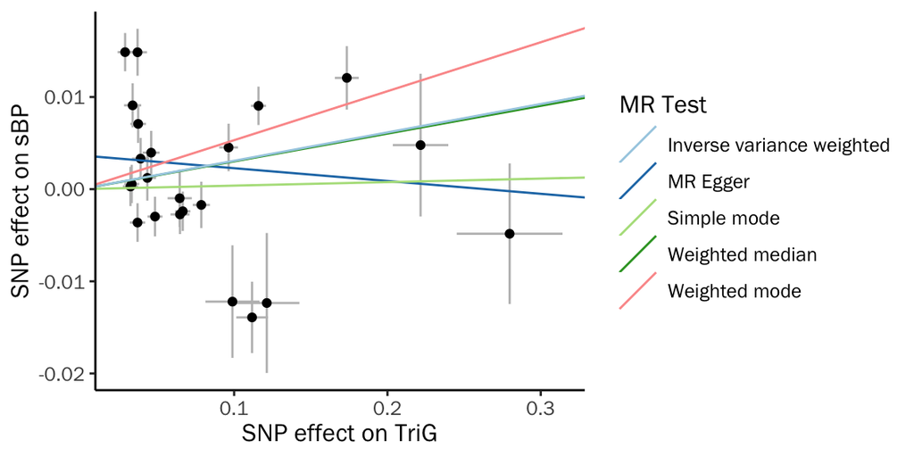

```r
# Scatter plot
scatter <- mr_scatter_plot(res, harm)
scatter[[1]] + theme + guides(color=guide_legend(ncol=1))
```

This scatter plot is a good way to examine the different MR regression methods. We can see that the IVW and MR-Egger results have different directions of effect, and that roughly half of the SNPs have opposing effects on plasma triglyceride level and systolic blood pressure.

Another useful plot is the leave-one-out plot, which can help identify any SNPs that have a large effect on the result.

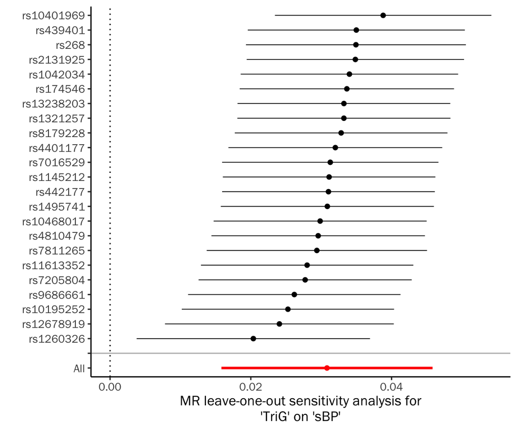

```r
# LOO plot
LOO <- mr_leaveoneout(harm, method=mr_ivw_fe)
mr_leaveoneout_plot(LOO)[[1]] + theme + theme(legend.position="none")
```

### 10. Outliers

Something else we can do is examine if there are any outliers in our analysis - outliers are SNPs that substantially contribute to the overall heterogeneity. We can use RadialMR to identify any outliers:

```r
# Identify outliers
radial <- harm %>% filter(mr_keep==TRUE) %>% dat_to_RadialMR
radialIVW <- ivw_radial(radial[[1]], alpha=0.05/nrow(radial[[1]]))
```

```
##
## Radial IVW
##
##                    Estimate   Std.Error  t value     Pr(>|t|)
## Effect (Mod.2nd) 0.03090395 0.020873880 1.480508 1.387377e-01
## Iterative        0.03090438 0.020873910 1.480527 1.387328e-01
## Exact (FE)       0.03290962 0.007680747 4.284689 1.829946e-05
## Exact (RE)       0.03110524 0.018924598 1.643641 1.144669e-01
##
##
## Residual standard error: 2.719 on 22 degrees of freedom
##
## F-statistic: 2.19 on 1 and 22 DF, p-value: 0.153
## Q-Statistic for heterogeneity: 162.6372 on 22 DF , p-value: 1.914582e-23
##
##  Outliers detected
## Number of iterations = 3
```

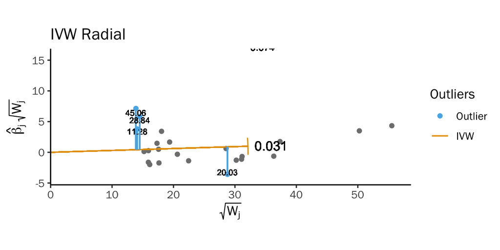

```r
# Radial plot
plot_radial(radialIVW, radial_scale=FALSE, show_outliers=TRUE) + theme
```

Then we can remove the outliers we identified and see how our results are affected.

```r
# Remove outliers
outliers <- radialIVW$outliers
TriGMRClumpedrmOutliers <- TriGMRClumped %>% filter(!SNP %in% outliers$SNP)

# Re-harmonise data
harm <- harmonise_data(exposure_dat=TriGMRClumpedrmOutliers, outcome_dat=sBPMR)

# MR
res <- mr(harm)
knitr::kable(res)
```

| id.exposure | id.outcome | outcome | exposure | method | nsnp | b | se | pval |
| --- | --- | --- | --- | --- | --- | --- | --- | --- |
| 1QhhMh | YcFEc9 | sBP | TriG | MR Egger | 19 | 0.0383116 | 0.0280671 | 0.1900468 |
| 1QhhMh | YcFEc9 | sBP | TriG | Weighted median | 19 | 0.0348414 | 0.0147743 | 0.0183620 |
| 1QhhMh | YcFEc9 | sBP | TriG | Inverse variance weighted | 19 | 0.0250642 | 0.0142645 | 0.0789006 |
| 1QhhMh | YcFEc9 | sBP | TriG | Simple mode | 19 | 0.0027901 | 0.0368017 | 0.9404040 |
| 1QhhMh | YcFEc9 | sBP | TriG | Weighted mode | 19 | 0.0599157 | 0.0161682 | 0.0016178 |

As these outliers are identified by their contribution to the overall heterogeneity of the analysis, when they are removed the overall heterogeneity should be reduced:

```r
# Heterogeneity
het <- mr_heterogeneity(harm)

# Single SNP
singleSNP <- mr_singlesnp(harm)
I2 <- Isq(singleSNP$b, singleSNP$se)

# Print
knitr::kable(het)
```

| id.exposure | id.outcome | outcome | exposure | method | Q | Q_df | Q_pval |
| --- | --- | --- | --- | --- | --- | --- | --- |
| 1QhhMh | YcFEc9 | sBP | TriG | MR Egger | 56.27195 | 17 | 4.3e-06 |
| 1QhhMh | YcFEc9 | sBP | TriG | Inverse variance weighted | 57.28027 | 18 | 5.6e-06 |

```r
message('I2: ', round(I2[1], 4))
```

```
## I2: 0.6521
```

Here we see that while the heterogeneity is not as extreme as before, it is still substantial, meaning the results from this analysis may be biased.

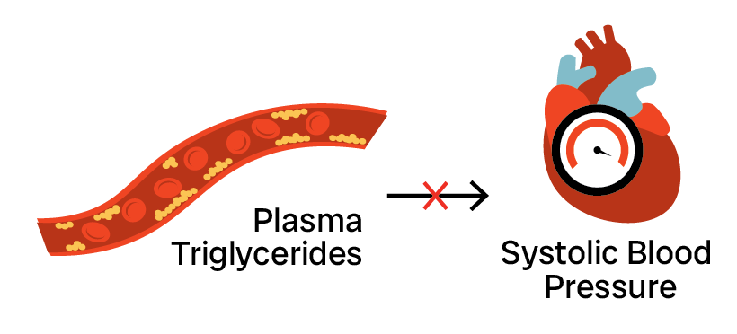

Some positives of this analysis are that the SNPs we selected as instrumental variables are sufficiently strong (F-stat=146), and that the exposure trait (plasma triglyceride levels) could be sufficiently modelled in MR by several strongly associated SNPs.

## MR & LCV

The LCV model is a similar method to MR that aims to identify causal effects between two traits using GWAS data. The results from applying the LCV model to the same GWAS datasets are [here](https://alicesmail12.github.io/Statistics/2024/07/09/Latent-Causal-Variable).

### Why do the results differ?

As the LCV model takes into account all SNPs from the input GWAS, it may be better powered to detect causal effects: MR only uses selected variants associated with exposure trait. It may be the case that this MR analysis was underpowered, relative to applying LCV, to detect a casual effect.